# IPL AUCTION

The TATA IPL 2022 mega auction is conducted on 12 and 13 February 2022 in Bengaluru.A total of 590 players were selected for the auction. 204 players were sold during the two-day IPL 2022 Auction. Young Indian cricketers dominated the proceedings at the auction. All and all, the ten franchises had two fruitful days at the mega auction and that sets up for a fascinating TATA IPL 2022. Let's take a look at summarised lowdown of the two-day event which includes costilest buy, expenditure of all teams, and all money spent in the span of two days.CSK, KKR, MI and PBKS were the only teams with 25 players each.

# IPL 2022 Auction summary

```
Chennai Super Kings - 25 players, 8 overseas, Rs 2.95 crore remaining
Delhi Capitals - 24 players, 7 overseas, Rs 10 lakh remaining
Kolkata Knight Riders - 25 players, 8 overseas, Rs 45 lakh remaining
Mumbai Indians - 25 players, 8 overseas, Rs 10 lakh remaining
Punjab Kings - 25 players, 7 overseas, Rs 3.45 crore remaining
Rajasthan Royals - 24 players, 8 overseas, Rs 95 lakh remaining
Royal Challengers Bangalore - 22 players, 8 overseas, Rs 1.55 crore remaining
Sunrisers Hyderabad - 23 players, 8 overseas, Rs 10 lakh remaining
Lucknow Super Giant- 21 players, 7 overseas, Rs 0 remaining
Gujarat Titans- 23 players, 8 overseas, Rs 15 lakh remaining
```

# Indian players

A total of 370 Indian cricketers and 220 international cricketers would be up for grabs, with up to 48 players opting for the Rs 2 crore tier.

# Foreign players

The franchises target pacers Trent Boult, Pat Cummins, and Kagiso Rabada, as well as the Australian all-rounders Mitchell Marsh and Steve Smith, former Bangladesh captain Shakib Al Hasan, and big-hitting South African Faf du Plessis. They have all qualified for the top bracket.According to a PTI report, Indian legends Suresh Raina and Robin Uthappa may not find many takers at an introductory price of Rs 2 crore.Twenty athletes have a reserve price of Rs 1.5 crore on the auction list, while 34 cricketers have a reserve price of Rs 1 crore.

# Importing all the required libraries

```python
import pandas as pd
import numpy as np
import matplotlib
import matplotlib.pyplot as plt
from matplotlib import pyplot as plt   # import matplotlib.pyplot as plt
from matplotlib import style
import seaborn as sns

import warnings
warnings.filterwarnings("ignore")
%matplotlib inline
```

# Reading the dataset

```python
IPL=pd.read_csv("C:\\Users\\Tanuja\\Desktop\\DATA-SET\\IPL_Auction_2022_FullList.csv")
```

# Viewing the all IPL data:

```python
IPL
```

|  | Set No. | Set Name | Player | Country | State Association | Age | Specialism | Batting | Bowling | IPL | Previous IPLTeam(s) | 2021 Team | C/U/A | Base Price | Sold Price | New Franchise | Bid | Increase Percentage |
| --- | --- | --- | --- | --- | --- | --- | --- | --- | --- | --- | --- | --- | --- | --- | --- | --- | --- | --- |
| 0 | 1 | M | Trent Boult | New Zealand | NaN | 32 | BOWLER | RHB | LEFT ARM Fast Medium | 62.0 | SRH, KKR, DD,MI | MI | Capped | 200 | 8 CR | Rajasthan Royals | Sold | 300.0 |
| 1 | 1 | M | Pat Cummins | Australia | NaN | 28 | ALL-ROUNDER | RHB | RIGHT ARM Fast | 37.0 | DD, MI, KKR | KKR | Capped | 200 | 7.25 CR | Kolkata Knight Riders | Sold | 262.5 |
| 2 | 1 | M | Shikhar Dhawan | India | DDCA | 36 | BATSMAN | LHB | - | 192.0 | DCH, MI, SRH, DC | DC | Capped | 200 | 8.25 CR | Punjab Kings | Sold | 312.5 |
| 3 | 1 | M | Shreyas Iyer | India | MCA | 27 | BATSMAN | RHB | RIGHT ARM Leg Spin | 87.0 | DC | DC | Capped | 200 | 12.25 CR | Kolkata Knight Riders | Sold | 512.5 |
| 4 | 1 | M | Kagiso Rabada | South Africa | NaN | 26 | BOWLER | LHB | RIGHT ARM Fast | 50.0 | DC | DC | Capped | 200 | 9.25 CR | Punjab Kings | Sold | 362.5 |
| ... | ... | ... | ... | ... | ... | ... | ... | ... | ... | ... | ... | ... | ... | ... | ... | ... | ... | ... |
| 584 | 62 | UAL15 | Safyaan Sharif | Scotland | NaN | 30 | ALL-ROUNDER | RHB | RIGHT ARM Fast Medium | NaN | NaN | NaN | Associate | 20 | NaN | NaN | UnSold | NaN |
| 585 | 62 | UAL15 | Henry Shipley | New Zealand | NaN | 25 | ALL-ROUNDER | RHB | RIGHT ARM Fast Medium | NaN | NaN | NaN | Uncapped | 20 | NaN | NaN | UnSold | NaN |
| 586 | 62 | UAL15 | Maxwell Swaminathan | India | MCA | 23 | ALL-ROUNDER | RHB | RIGHT ARM Off Spin | NaN | NaN | NaN | Uncapped | 20 | NaN | NaN | UnSold | NaN |
| 587 | 62 | UAL15 | Johan Van Dyk | South Africa | NaN | 28 | ALL-ROUNDER | RHB | RIGHT ARM Fast Medium | NaN | NaN | NaN | Uncapped | 20 | NaN | NaN | UnSold | NaN |
| 588 | 62 | UAL15 | Dunith Wellalage | Sri Lanka | NaN | 19 | ALL-ROUNDER | LHB | LEFT ARM Slow Orthodox | NaN | NaN | NaN | Uncapped | 20 | NaN | NaN | UnSold | NaN |

589 rows × 18 columns

# Checking how many rows and columns are there in IPL dataset:

```python
IPL.shape
```

```
(589, 18)
```

# Printing IPL columns names:

```python
IPL.columns
```

```
Index(['Set No.', 'Set Name', 'Player', 'Country', 'State Association', 'Age',
       'Specialism', 'Batting', 'Bowling', 'IPL', 'Previous IPLTeam(s)',
       '2021 Team', 'C/U/A', 'Base Price', 'Sold Price', 'New Franchise',
       'Bid', 'Increase Percentage'],
      dtype='object')
```

# To check the datatypes of attributes:

```python
IPL.dtypes
```

```
Set No.                  int64
Set Name                object
Player                  object
Country                 object
State Association       object
Age                      int64
Specialism              object
Batting                 object
Bowling                 object
IPL                    float64
Previous IPLTeam(s)     object
2021 Team               object
C/U/A                   object
Base Price               int64
Sold Price              object
New Franchise           object
Bid                     object
Increase Percentage    float64
dtype: object
```

# Printing the top 5 records of IPL:

```python
IPL.head()
```

|  | Set No. | Set Name | Player | Country | State Association | Age | Specialism | Batting | Bowling | IPL | Previous IPLTeam(s) | 2021 Team | C/U/A | Base Price | Sold Price | New Franchise | Bid | Increase Percentage |
| --- | --- | --- | --- | --- | --- | --- | --- | --- | --- | --- | --- | --- | --- | --- | --- | --- | --- | --- |
| 0 | 1 | M | Trent Boult | New Zealand | NaN | 32 | BOWLER | RHB | LEFT ARM Fast Medium | 62.0 | SRH, KKR, DD,MI | MI | Capped | 200 | 8 CR | Rajasthan Royals | Sold | 300.0 |
| 1 | 1 | M | Pat Cummins | Australia | NaN | 28 | ALL-ROUNDER | RHB | RIGHT ARM Fast | 37.0 | DD, MI, KKR | KKR | Capped | 200 | 7.25 CR | Kolkata Knight Riders | Sold | 262.5 |
| 2 | 1 | M | Shikhar Dhawan | India | DDCA | 36 | BATSMAN | LHB | - | 192.0 | DCH, MI, SRH, DC | DC | Capped | 200 | 8.25 CR | Punjab Kings | Sold | 312.5 |
| 3 | 1 | M | Shreyas Iyer | India | MCA | 27 | BATSMAN | RHB | RIGHT ARM Leg Spin | 87.0 | DC | DC | Capped | 200 | 12.25 CR | Kolkata Knight Riders | Sold | 512.5 |
| 4 | 1 | M | Kagiso Rabada | South Africa | NaN | 26 | BOWLER | LHB | RIGHT ARM Fast | 50.0 | DC | DC | Capped | 200 | 9.25 CR | Punjab Kings | Sold | 362.5 |

# Printing the bottom 5 records of IPL:

```python
IPL.tail()
```

|  | Set No. | Set Name | Player | Country | State Association | Age | Specialism | Batting | Bowling | IPL | Previous IPLTeam(s) | 2021 Team | C/U/A | Base Price | Sold Price | New Franchise | Bid | Increase Percentage |
| --- | --- | --- | --- | --- | --- | --- | --- | --- | --- | --- | --- | --- | --- | --- | --- | --- | --- | --- |
| 584 | 62 | UAL15 | Safyaan Sharif | Scotland | NaN | 30 | ALL-ROUNDER | RHB | RIGHT ARM Fast Medium | NaN | NaN | NaN | Associate | 20 | NaN | NaN | UnSold | NaN |
| 585 | 62 | UAL15 | Henry Shipley | New Zealand | NaN | 25 | ALL-ROUNDER | RHB | RIGHT ARM Fast Medium | NaN | NaN | NaN | Uncapped | 20 | NaN | NaN | UnSold | NaN |
| 586 | 62 | UAL15 | Maxwell Swaminathan | India | MCA | 23 | ALL-ROUNDER | RHB | RIGHT ARM Off Spin | NaN | NaN | NaN | Uncapped | 20 | NaN | NaN | UnSold | NaN |
| 587 | 62 | UAL15 | Johan Van Dyk | South Africa | NaN | 28 | ALL-ROUNDER | RHB | RIGHT ARM Fast Medium | NaN | NaN | NaN | Uncapped | 20 | NaN | NaN | UnSold | NaN |
| 588 | 62 | UAL15 | Dunith Wellalage | Sri Lanka | NaN | 19 | ALL-ROUNDER | LHB | LEFT ARM Slow Orthodox | NaN | NaN | NaN | Uncapped | 20 | NaN | NaN | UnSold | NaN |

# Reading specific rows:

```python
IPL[1:31]["Previous IPLTeam(s)"]
```

```
1                    DD, MI, KKR
2               DCH, MI, SRH, DC
3                             DC
4                             DC
5             DCH, KKR, DD, PBKS
6             CSK, RSP, KXIP, DC
7               SRH, DD, RCB, MI
8                       RPS, CSK
9                        DD, SRH
10                       RCB, DC
11                      KXIP, RR
12                           RCB
13        MI, RCB, PWI, KKR, SRH
14                   GL, DC, SRH
15    MI, PWI, RCB, KKR, RR, CSK
```

[output cut: 16 more lines]

# Reading specific rows and columns:

```python
IPL.loc[[100,150,200,250,300,350,400,450,500,550],["Player","Country","State Association","Age","Specialism"]]
```

|  | Player | Country | State Association | Age | Specialism |
| --- | --- | --- | --- | --- | --- |
| 100 | Manan Vohra | India | UTCA | 28 | BATSMAN |
| 150 | Mayank Yadav | India | DDCA | 19 | BOWLER |
| 200 | Vishnu Solanki | India | BCA | 29 | WICKETKEEPER |
| 250 | Andrew Tye | Australia | NaN | 35 | BOWLER |
| 300 | Hazratullah Zazai | Afghanistan | NaN | 24 | BATSMAN |
| 350 | Chintal Gandhi | India | BCA | 27 | BOWLER |
| 400 | Rahul Chandrol | India | MPCA | 21 | WICKETKEEPER |
| 450 | Shashwat Rawat | India | BCA | 21 | BATSMAN |
| 500 | Mohd. Arshad Khan | India | MPCA | 24 | ALL-ROUNDER |
| 550 | Pulkit Narang | India | SSCB | 27 | ALL-ROUNDER |

# Information of IPL dataset:

```python
IPL.info()
```

```
<class 'pandas.core.frame.DataFrame'>
RangeIndex: 589 entries, 0 to 588
Data columns (total 18 columns):
 #   Column               Non-Null Count  Dtype
---  ------               --------------  -----
 0   Set No.              589 non-null    int64
 1   Set Name             589 non-null    object
 2   Player               589 non-null    object
 3   Country              589 non-null    object
 4   State Association    369 non-null    object
 5   Age                  589 non-null    int64
 6   Specialism           589 non-null    object
 7   Batting              589 non-null    object
 8   Bowling              589 non-null    object
 9   IPL                  270 non-null    float64
 10  Previous IPLTeam(s)  265 non-null    object
 11  2021 Team            165 non-null    object
 12  C/U/A                589 non-null    object
 13  Base Price           589 non-null    int64
 14  Sold Price           204 non-null    object
 15  New Franchise        204 non-null    object
 16  Bid                  589 non-null    object
 17  Increase Percentage  204 non-null    float64
dtypes: float64(2), int64(3), object(13)
memory usage: 83.0+ KB
```

# Statistical Information of IPL dataset:

```python
IPL.describe()
```

|  | Set No. | Age | IPL | Base Price | Increase Percentage |
| --- | --- | --- | --- | --- | --- |
| count | 589.000000 | 589.000000 | 270.000000 | 589.000000 | 204.000000 |
| mean | 32.096774 | 26.955857 | 29.425926 | 51.926995 | 306.552299 |
| std | 17.890516 | 4.690208 | 42.904494 | 53.467166 | 595.650107 |
| min | 1.000000 | 17.000000 | 0.000000 | 20.000000 | 0.000000 |
| 25% | 17.000000 | 23.000000 | 1.000000 | 20.000000 | 0.000000 |
| 50% | 32.000000 | 27.000000 | 10.500000 | 20.000000 | 50.000000 |
| 75% | 48.000000 | 30.000000 | 38.750000 | 50.000000 | 300.000000 |
| max | 62.000000 | 43.000000 | 213.000000 | 200.000000 | 4900.000000 |

```python
IPL.describe(include="all")
```

|  | Set No. | Set Name | Player | Country | State Association | Age | Specialism | Batting | Bowling | IPL | Previous IPLTeam(s) | 2021 Team | C/U/A | Base Price | Sold Price | New Franchise | Bid | Increase Percentage |
| --- | --- | --- | --- | --- | --- | --- | --- | --- | --- | --- | --- | --- | --- | --- | --- | --- | --- | --- |
| count | 589.000000 | 589 | 589 | 589 | 369 | 589.000000 | 589 | 589 | 589 | 270.000000 | 265 | 165 | 589 | 589.000000 | 204 | 204 | 589 | 204.000000 |
| unique | NaN | 62 | 586 | 15 | 34 | NaN | 4 | 2 | 11 | NaN | 137 | 8 | 3 | NaN | 66 | 12 | 2 | NaN |
| top | NaN | UAL15 | Amit Mishra | India | TNCA | NaN | ALL-ROUNDER | RHB | RIGHT ARM Fast Medium | NaN | RCB | SRH | Uncapped | NaN | 20 L | Punjab Kings | UnSold | NaN |
| freq | NaN | 12 | 2 | 369 | 30 | NaN | 227 | 415 | 126 | NaN | 20 | 22 | 354 | NaN | 53 | 23 | 385 | NaN |
| mean | 32.096774 | NaN | NaN | NaN | NaN | 26.955857 | NaN | NaN | NaN | 29.425926 | NaN | NaN | NaN | 51.926995 | NaN | NaN | NaN | 306.552299 |
| std | 17.890516 | NaN | NaN | NaN | NaN | 4.690208 | NaN | NaN | NaN | 42.904494 | NaN | NaN | NaN | 53.467166 | NaN | NaN | NaN | 595.650107 |
| min | 1.000000 | NaN | NaN | NaN | NaN | 17.000000 | NaN | NaN | NaN | 0.000000 | NaN | NaN | NaN | 20.000000 | NaN | NaN | NaN | 0.000000 |
| 25% | 17.000000 | NaN | NaN | NaN | NaN | 23.000000 | NaN | NaN | NaN | 1.000000 | NaN | NaN | NaN | 20.000000 | NaN | NaN | NaN | 0.000000 |
| 50% | 32.000000 | NaN | NaN | NaN | NaN | 27.000000 | NaN | NaN | NaN | 10.500000 | NaN | NaN | NaN | 20.000000 | NaN | NaN | NaN | 50.000000 |
| 75% | 48.000000 | NaN | NaN | NaN | NaN | 30.000000 | NaN | NaN | NaN | 38.750000 | NaN | NaN | NaN | 50.000000 | NaN | NaN | NaN | 300.000000 |
| max | 62.000000 | NaN | NaN | NaN | NaN | 43.000000 | NaN | NaN | NaN | 213.000000 | NaN | NaN | NaN | 200.000000 | NaN | NaN | NaN | 4900.000000 |

# Overall count of IPL dataset:

```python
IPL.count()
```

```
Set No.                589
Set Name               589
Player                 589
Country                589
State Association      369
Age                    589
Specialism             589
Batting                589
Bowling                589
IPL                    270
Previous IPLTeam(s)    265
2021 Team              165
C/U/A                  589
Base Price             589
Sold Price             204
New Franchise          204
Bid                    589
Increase Percentage    204
dtype: int64
```

# Print some random lines:

```python
IPL.sample(5)
```

|  | Set No. | Set Name | Player | Country | State Association | Age | Specialism | Batting | Bowling | IPL | Previous IPLTeam(s) | 2021 Team | C/U/A | Base Price | Sold Price | New Franchise | Bid | Increase Percentage |
| --- | --- | --- | --- | --- | --- | --- | --- | --- | --- | --- | --- | --- | --- | --- | --- | --- | --- | --- |
| 237 | 20 | AL3 | Charith Asalanka | Sri Lanka | NaN | 24 | ALL-ROUNDER | LHB | RIGHT ARM Leg Spin | NaN | NaN | NaN | Capped | 50 | NaN | NaN | UnSold | NaN |
| 561 | 60 | UAL13 | Siddhant Sharma | India | DDCA | 25 | ALL-ROUNDER | LHB | LEFT ARM Medium | NaN | NaN | NaN | Uncapped | 20 | NaN | NaN | UnSold | NaN |
| 84 | 13 | AL2 | Liam Livingstone | England | NaN | 28 | ALL-ROUNDER | RHB | RIGHT ARM Leg Spin | 9.0 | RR | RR | Capped | 100 | 11.50 CR | Punjab Kings | Sold | 1050.0 |
| 172 | 47 | UBA6 | Ramesh Kumar | India | PCA | 23 | BATSMAN | LHB | - | NaN | NaN | NaN | Uncapped | 20 | 20 L | Kolkata Knight Riders | Sold | 0.0 |
| 21 | 3 | AL1 | Harshal Patel | India | HCA | 31 | ALL-ROUNDER | RHB | RIGHT ARM Fast Medium | 63.0 | DC, RCB | RCB | Capped | 200 | 10.75 CR | Royal Challengers Bangalore | Sold | 437.5 |

# nunique(): number of unique values

```
> nunique() function return number of unique elements in the object.
> It returns a scalar value which is the count of all the unique values in the Index.
> By default the NaN values are not included in the count.
> If dropna parameter is set to be False then it includes NaN value in the count.
```

```python
IPL.nunique()
```

```
Set No.                 62
Set Name                62
Player                 586
Country                 15
State Association       34
Age                     25
Specialism               4
Batting                  2
Bowling                 11
IPL                     86
Previous IPLTeam(s)    137
2021 Team                8
C/U/A                    3
Base Price               8
Sold Price              66
New Franchise           12
Bid                      2
Increase Percentage     69
dtype: int64
```

# Correlation():

```python
IPL.corr()
```

|  | Set No. | Age | IPL | Base Price | Increase Percentage |
| --- | --- | --- | --- | --- | --- |
| Set No. | 1.000000 | -0.217646 | -0.392722 | -0.533670 | -0.274668 |
| Age | -0.217646 | 1.000000 | 0.463484 | 0.436103 | -0.164773 |
| IPL | -0.392722 | 0.463484 | 1.000000 | 0.511262 | -0.040509 |
| Base Price | -0.533670 | 0.436103 | 0.511262 | 1.000000 | -0.086065 |
| Increase Percentage | -0.274668 | -0.164773 | -0.040509 | -0.086065 | 1.000000 |

# Co-varience():

```python
IPL.cov()
```

|  | Set No. | Age | IPL | Base Price | Increase Percentage |
| --- | --- | --- | --- | --- | --- |
| Set No. | 320.070551 | -18.262728 | -260.735646 | -510.484420 | -2291.331603 |
| Age | -18.262728 | 21.998048 | 88.418698 | 109.362418 | -441.475299 |
| IPL | -260.735646 | 88.418698 | 1840.795608 | 1439.412777 | -1213.096259 |
| Base Price | -510.484420 | 109.362418 | 1439.412777 | 2858.737858 | -3454.434483 |
| Increase Percentage | -2291.331603 | -441.475299 | -1213.096259 | -3454.434483 | 354799.050470 |

# To count number of countries:

```python
IPL["Country"].value_counts()
```

```
India           369
Australia        47
West Indies      34
South Africa     33
New Zealand      24
England          24
Sri Lanka        23
Afghanistan      17
Bangladesh        5
Ireland           5
Namibia           3
Scotland          2
Nepal             1
Zimbabwe          1
USA               1
Name: Country, dtype: int64
```

# To count number of specialism:

```python
IPL["Specialism"].value_counts()
```

```
ALL-ROUNDER     227
BOWLER          202
BATSMAN         102
WICKETKEEPER     58
Name: Specialism, dtype: int64
```

# To count number of Batting:

```python
IPL["Batting"].value_counts()
```

```
RHB    415
LHB    174
Name: Batting, dtype: int64
```

# To count number of Bowling:

```python
IPL["Bowling"].value_counts()
```

```
RIGHT ARM Fast Medium       126
RIGHT ARM Off Spin           97
RIGHT ARM Leg Spin           83
-                            74
RIGHT ARM Fast               60
LEFT ARM Slow Orthodox       58
LEFT ARM Fast Medium         34
LEFT ARM Fast                24
RIGHT ARM Medium             21
LEFT ARM Slow Unorthodox      9
LEFT ARM Medium               3
Name: Bowling, dtype: int64
```

# Checking the unique values for few columns:

```python
IPL["State Association"].unique()
```

```
array([nan, 'DDCA', 'MCA', 'CAB', 'TNCA', 'KSCA', 'KCA', 'BCA', 'HCA',
       'JSCA', 'ACA', 'RCA', 'UPCA', 'VCA', 'PCA', 'MACA', 'ASCA', 'SCA',
       'MPCA', 'UTCA', 'RSPB', 'GUCA', 'HPCA', 'OCA', 'GCA', 'JKCA',
       'HYCA', 'CSCSCA', 'BICA', 'NCA', 'SSCB', 'CAP', 'CAU', 'TCA',
       'MECA'], dtype=object)
```

```python
IPL["2021 Team"].unique()
```

```
array(['MI', 'KKR', 'DC', 'PBKS', 'CSK', 'SRH', 'RR', 'RCB', nan],
      dtype=object)
```

```python
IPL["New Franchise"].unique()
```

```
array(['Rajasthan Royals', 'Kolkata Knight Riders', 'Punjab Kings',
       'Gujarat Titans', 'Lucknow Super Giants',
       'Royal Challengers Bangalore', 'Delhi Capitals',
       'Chennai Super Kings', 'Sunrisers Hyderabad', 'Mumbai Indians',
       'Luknow Super Giants', 'Gujarat Titan', nan], dtype=object)
```

# To check is there any missing values:

```
> This function provides the boolean value for the complete dataset to know if any null value is present or not.
  can use isnull() or isna()
```

```python
IPL.isnull()
```

|  | Set No. | Set Name | Player | Country | State Association | Age | Specialism | Batting | Bowling | IPL | Previous IPLTeam(s) | 2021 Team | C/U/A | Base Price | Sold Price | New Franchise | Bid | Increase Percentage |
| --- | --- | --- | --- | --- | --- | --- | --- | --- | --- | --- | --- | --- | --- | --- | --- | --- | --- | --- |
| 0 | False | False | False | False | True | False | False | False | False | False | False | False | False | False | False | False | False | False |
| 1 | False | False | False | False | True | False | False | False | False | False | False | False | False | False | False | False | False | False |
| 2 | False | False | False | False | False | False | False | False | False | False | False | False | False | False | False | False | False | False |
| 3 | False | False | False | False | False | False | False | False | False | False | False | False | False | False | False | False | False | False |
| 4 | False | False | False | False | True | False | False | False | False | False | False | False | False | False | False | False | False | False |
| ... | ... | ... | ... | ... | ... | ... | ... | ... | ... | ... | ... | ... | ... | ... | ... | ... | ... | ... |
| 584 | False | False | False | False | True | False | False | False | False | True | True | True | False | False | True | True | False | True |
| 585 | False | False | False | False | True | False | False | False | False | True | True | True | False | False | True | True | False | True |
| 586 | False | False | False | False | False | False | False | False | False | True | True | True | False | False | True | True | False | True |
| 587 | False | False | False | False | True | False | False | False | False | True | True | True | False | False | True | True | False | True |
| 588 | False | False | False | False | True | False | False | False | False | True | True | True | False | False | True | True | False | True |

589 rows × 18 columns

```python
IPL.notnull()
```

|  | Set No. | Set Name | Player | Country | State Association | Age | Specialism | Batting | Bowling | IPL | Previous IPLTeam(s) | 2021 Team | C/U/A | Base Price | Sold Price | New Franchise | Bid | Increase Percentage |
| --- | --- | --- | --- | --- | --- | --- | --- | --- | --- | --- | --- | --- | --- | --- | --- | --- | --- | --- |
| 0 | True | True | True | True | False | True | True | True | True | True | True | True | True | True | True | True | True | True |
| 1 | True | True | True | True | False | True | True | True | True | True | True | True | True | True | True | True | True | True |
| 2 | True | True | True | True | True | True | True | True | True | True | True | True | True | True | True | True | True | True |
| 3 | True | True | True | True | True | True | True | True | True | True | True | True | True | True | True | True | True | True |
| 4 | True | True | True | True | False | True | True | True | True | True | True | True | True | True | True | True | True | True |
| ... | ... | ... | ... | ... | ... | ... | ... | ... | ... | ... | ... | ... | ... | ... | ... | ... | ... | ... |
| 584 | True | True | True | True | False | True | True | True | True | False | False | False | True | True | False | False | True | False |
| 585 | True | True | True | True | False | True | True | True | True | False | False | False | True | True | False | False | True | False |
| 586 | True | True | True | True | True | True | True | True | True | False | False | False | True | True | False | False | True | False |
| 587 | True | True | True | True | False | True | True | True | True | False | False | False | True | True | False | False | True | False |
| 588 | True | True | True | True | False | True | True | True | True | False | False | False | True | True | False | False | True | False |

589 rows × 18 columns

# Using isnull().any()

```
> This function also gives a boolean value if any null value is present or not, but it gives results column-wise,
  not in tabular format.
```

```python
IPL.isnull().any()
```

```
Set No.                False
Set Name               False
Player                 False
Country                False
State Association       True
Age                    False
Specialism             False
Batting                False
Bowling                False
IPL                     True
Previous IPLTeam(s)     True
2021 Team               True
C/U/A                  False
Base Price             False
Sold Price              True
New Franchise           True
Bid                    False
Increase Percentage     True
dtype: bool
```

# Using isnull().sum()

```
> This function gives the sum of the null values preset in the dataset column-wise.
```

```python
IPL.isnull().sum()
```

```
Set No.                  0
Set Name                 0
Player                   0
Country                  0
State Association      220
Age                      0
Specialism               0
Batting                  0
Bowling                  0
IPL                    319
Previous IPLTeam(s)    324
2021 Team              424
C/U/A                    0
Base Price               0
Sold Price             385
New Franchise          385
Bid                      0
Increase Percentage    385
dtype: int64
```

# Using isnull.any().sum()

```
> This function gives output in a single value if any null is present or not.
```

```python
IPL.isnull().any().sum()
```

```
7
```

# To check is there any duplicated value in IPL dataset:

```python
IPL.duplicated()
```

```
0      False
1      False
2      False
3      False
4      False
       ...
584    False
585    False
586    False
587    False
588    False
Length: 589, dtype: bool
```

```python
IPL.duplicated().sum()
```

```
0
```

```python
IPL.duplicated().count()
```

```
589
```

# Copy the IPL dataset to IPL1:

```python
IPL1=IPL.copy()
IPL1
```

|  | Set No. | Set Name | Player | Country | State Association | Age | Specialism | Batting | Bowling | IPL | Previous IPLTeam(s) | 2021 Team | C/U/A | Base Price | Sold Price | New Franchise | Bid | Increase Percentage |
| --- | --- | --- | --- | --- | --- | --- | --- | --- | --- | --- | --- | --- | --- | --- | --- | --- | --- | --- |
| 0 | 1 | M | Trent Boult | New Zealand | NaN | 32 | BOWLER | RHB | LEFT ARM Fast Medium | 62.0 | SRH, KKR, DD,MI | MI | Capped | 200 | 8 CR | Rajasthan Royals | Sold | 300.0 |
| 1 | 1 | M | Pat Cummins | Australia | NaN | 28 | ALL-ROUNDER | RHB | RIGHT ARM Fast | 37.0 | DD, MI, KKR | KKR | Capped | 200 | 7.25 CR | Kolkata Knight Riders | Sold | 262.5 |
| 2 | 1 | M | Shikhar Dhawan | India | DDCA | 36 | BATSMAN | LHB | - | 192.0 | DCH, MI, SRH, DC | DC | Capped | 200 | 8.25 CR | Punjab Kings | Sold | 312.5 |
| 3 | 1 | M | Shreyas Iyer | India | MCA | 27 | BATSMAN | RHB | RIGHT ARM Leg Spin | 87.0 | DC | DC | Capped | 200 | 12.25 CR | Kolkata Knight Riders | Sold | 512.5 |
| 4 | 1 | M | Kagiso Rabada | South Africa | NaN | 26 | BOWLER | LHB | RIGHT ARM Fast | 50.0 | DC | DC | Capped | 200 | 9.25 CR | Punjab Kings | Sold | 362.5 |
| ... | ... | ... | ... | ... | ... | ... | ... | ... | ... | ... | ... | ... | ... | ... | ... | ... | ... | ... |
| 584 | 62 | UAL15 | Safyaan Sharif | Scotland | NaN | 30 | ALL-ROUNDER | RHB | RIGHT ARM Fast Medium | NaN | NaN | NaN | Associate | 20 | NaN | NaN | UnSold | NaN |
| 585 | 62 | UAL15 | Henry Shipley | New Zealand | NaN | 25 | ALL-ROUNDER | RHB | RIGHT ARM Fast Medium | NaN | NaN | NaN | Uncapped | 20 | NaN | NaN | UnSold | NaN |
| 586 | 62 | UAL15 | Maxwell Swaminathan | India | MCA | 23 | ALL-ROUNDER | RHB | RIGHT ARM Off Spin | NaN | NaN | NaN | Uncapped | 20 | NaN | NaN | UnSold | NaN |
| 587 | 62 | UAL15 | Johan Van Dyk | South Africa | NaN | 28 | ALL-ROUNDER | RHB | RIGHT ARM Fast Medium | NaN | NaN | NaN | Uncapped | 20 | NaN | NaN | UnSold | NaN |
| 588 | 62 | UAL15 | Dunith Wellalage | Sri Lanka | NaN | 19 | ALL-ROUNDER | LHB | LEFT ARM Slow Orthodox | NaN | NaN | NaN | Uncapped | 20 | NaN | NaN | UnSold | NaN |

589 rows × 18 columns

# fillna():

[output not shown]

```python
IPL1=pd.DataFrame(IPL,columns=["Country","Player","State Association","IPL","Sold Price","Base Price",
                               "Previous IPLTeam(s)","2021 Team","Bid","New Franchise","Increase Percentage"])
IPL1
```

|  | Country | Player | State Association | IPL | Sold Price | Base Price | Previous IPLTeam(s) | 2021 Team | Bid | New Franchise | Increase Percentage |
| --- | --- | --- | --- | --- | --- | --- | --- | --- | --- | --- | --- |
| 0 | New Zealand | Trent Boult | NaN | 62.0 | 8 CR | 200 | SRH, KKR, DD,MI | MI | Sold | Rajasthan Royals | 300.0 |
| 1 | Australia | Pat Cummins | NaN | 37.0 | 7.25 CR | 200 | DD, MI, KKR | KKR | Sold | Kolkata Knight Riders | 262.5 |
| 2 | India | Shikhar Dhawan | DDCA | 192.0 | 8.25 CR | 200 | DCH, MI, SRH, DC | DC | Sold | Punjab Kings | 312.5 |
| 3 | India | Shreyas Iyer | MCA | 87.0 | 12.25 CR | 200 | DC | DC | Sold | Kolkata Knight Riders | 512.5 |
| 4 | South Africa | Kagiso Rabada | NaN | 50.0 | 9.25 CR | 200 | DC | DC | Sold | Punjab Kings | 362.5 |
| ... | ... | ... | ... | ... | ... | ... | ... | ... | ... | ... | ... |
| 584 | Scotland | Safyaan Sharif | NaN | NaN | NaN | 20 | NaN | NaN | UnSold | NaN | NaN |
| 585 | New Zealand | Henry Shipley | NaN | NaN | NaN | 20 | NaN | NaN | UnSold | NaN | NaN |
| 586 | India | Maxwell Swaminathan | MCA | NaN | NaN | 20 | NaN | NaN | UnSold | NaN | NaN |
| 587 | South Africa | Johan Van Dyk | NaN | NaN | NaN | 20 | NaN | NaN | UnSold | NaN | NaN |
| 588 | Sri Lanka | Dunith Wellalage | NaN | NaN | NaN | 20 | NaN | NaN | UnSold | NaN | NaN |

589 rows × 11 columns

```python
IPL1["State Association"].fillna("F",inplace=True)
IPL1["IPL"].fillna(0,inplace=True)
IPL1["Sold Price"].fillna("0 CR",inplace=True)
IPL1["Previous IPLTeam(s)"].fillna("Do No Play",inplace=True)
IPL1["2021 Team"].fillna("DNP",inplace=True)
IPL1["New Franchise"].fillna("Not Selected",inplace=True)
IPL1["Increase Percentage"].fillna(0,inplace=True)
```

```python
IPL1
```

|  | Country | Player | State Association | IPL | Sold Price | Base Price | Previous IPLTeam(s) | 2021 Team | Bid | New Franchise | Increase Percentage |
| --- | --- | --- | --- | --- | --- | --- | --- | --- | --- | --- | --- |
| 0 | New Zealand | Trent Boult | F | 62.0 | 8 CR | 200 | SRH, KKR, DD,MI | MI | Sold | Rajasthan Royals | 300.0 |
| 1 | Australia | Pat Cummins | F | 37.0 | 7.25 CR | 200 | DD, MI, KKR | KKR | Sold | Kolkata Knight Riders | 262.5 |
| 2 | India | Shikhar Dhawan | DDCA | 192.0 | 8.25 CR | 200 | DCH, MI, SRH, DC | DC | Sold | Punjab Kings | 312.5 |
| 3 | India | Shreyas Iyer | MCA | 87.0 | 12.25 CR | 200 | DC | DC | Sold | Kolkata Knight Riders | 512.5 |
| 4 | South Africa | Kagiso Rabada | F | 50.0 | 9.25 CR | 200 | DC | DC | Sold | Punjab Kings | 362.5 |
| ... | ... | ... | ... | ... | ... | ... | ... | ... | ... | ... | ... |
| 584 | Scotland | Safyaan Sharif | F | 0.0 | 0 CR | 20 | Do No Play | DNP | UnSold | Not Selected | 0.0 |
| 585 | New Zealand | Henry Shipley | F | 0.0 | 0 CR | 20 | Do No Play | DNP | UnSold | Not Selected | 0.0 |
| 586 | India | Maxwell Swaminathan | MCA | 0.0 | 0 CR | 20 | Do No Play | DNP | UnSold | Not Selected | 0.0 |
| 587 | South Africa | Johan Van Dyk | F | 0.0 | 0 CR | 20 | Do No Play | DNP | UnSold | Not Selected | 0.0 |
| 588 | Sri Lanka | Dunith Wellalage | F | 0.0 | 0 CR | 20 | Do No Play | DNP | UnSold | Not Selected | 0.0 |

589 rows × 11 columns

# Converting CR into Lakhs:

```python
def change(item):
    price = item.split()
    if price[1] == "CR":
        return float(price[0])*100
    else:
        return float(price[0])

IPL1["Sold Price"] = IPL1["Sold Price"].apply(lambda item: change(item))
```

```python
IPL1
```

|  | Country | Player | State Association | IPL | Sold Price | Base Price | Previous IPLTeam(s) | 2021 Team | Bid | New Franchise | Increase Percentage |
| --- | --- | --- | --- | --- | --- | --- | --- | --- | --- | --- | --- |
| 0 | New Zealand | Trent Boult | F | 62.0 | 800.0 | 200 | SRH, KKR, DD,MI | MI | Sold | Rajasthan Royals | 300.0 |
| 1 | Australia | Pat Cummins | F | 37.0 | 725.0 | 200 | DD, MI, KKR | KKR | Sold | Kolkata Knight Riders | 262.5 |
| 2 | India | Shikhar Dhawan | DDCA | 192.0 | 825.0 | 200 | DCH, MI, SRH, DC | DC | Sold | Punjab Kings | 312.5 |
| 3 | India | Shreyas Iyer | MCA | 87.0 | 1225.0 | 200 | DC | DC | Sold | Kolkata Knight Riders | 512.5 |
| 4 | South Africa | Kagiso Rabada | F | 50.0 | 925.0 | 200 | DC | DC | Sold | Punjab Kings | 362.5 |
| ... | ... | ... | ... | ... | ... | ... | ... | ... | ... | ... | ... |
| 584 | Scotland | Safyaan Sharif | F | 0.0 | 0.0 | 20 | Do No Play | DNP | UnSold | Not Selected | 0.0 |
| 585 | New Zealand | Henry Shipley | F | 0.0 | 0.0 | 20 | Do No Play | DNP | UnSold | Not Selected | 0.0 |
| 586 | India | Maxwell Swaminathan | MCA | 0.0 | 0.0 | 20 | Do No Play | DNP | UnSold | Not Selected | 0.0 |
| 587 | South Africa | Johan Van Dyk | F | 0.0 | 0.0 | 20 | Do No Play | DNP | UnSold | Not Selected | 0.0 |
| 588 | Sri Lanka | Dunith Wellalage | F | 0.0 | 0.0 | 20 | Do No Play | DNP | UnSold | Not Selected | 0.0 |

589 rows × 11 columns

# Copy IPL dataset into IPL2:

```python
IPL2=IPL.copy()
IPL2
```

|  | Set No. | Set Name | Player | Country | State Association | Age | Specialism | Batting | Bowling | IPL | Previous IPLTeam(s) | 2021 Team | C/U/A | Base Price | Sold Price | New Franchise | Bid | Increase Percentage |
| --- | --- | --- | --- | --- | --- | --- | --- | --- | --- | --- | --- | --- | --- | --- | --- | --- | --- | --- |
| 0 | 1 | M | Trent Boult | New Zealand | NaN | 32 | BOWLER | RHB | LEFT ARM Fast Medium | 62.0 | SRH, KKR, DD,MI | MI | Capped | 200 | 8 CR | Rajasthan Royals | Sold | 300.0 |
| 1 | 1 | M | Pat Cummins | Australia | NaN | 28 | ALL-ROUNDER | RHB | RIGHT ARM Fast | 37.0 | DD, MI, KKR | KKR | Capped | 200 | 7.25 CR | Kolkata Knight Riders | Sold | 262.5 |
| 2 | 1 | M | Shikhar Dhawan | India | DDCA | 36 | BATSMAN | LHB | - | 192.0 | DCH, MI, SRH, DC | DC | Capped | 200 | 8.25 CR | Punjab Kings | Sold | 312.5 |
| 3 | 1 | M | Shreyas Iyer | India | MCA | 27 | BATSMAN | RHB | RIGHT ARM Leg Spin | 87.0 | DC | DC | Capped | 200 | 12.25 CR | Kolkata Knight Riders | Sold | 512.5 |
| 4 | 1 | M | Kagiso Rabada | South Africa | NaN | 26 | BOWLER | LHB | RIGHT ARM Fast | 50.0 | DC | DC | Capped | 200 | 9.25 CR | Punjab Kings | Sold | 362.5 |
| ... | ... | ... | ... | ... | ... | ... | ... | ... | ... | ... | ... | ... | ... | ... | ... | ... | ... | ... |
| 584 | 62 | UAL15 | Safyaan Sharif | Scotland | NaN | 30 | ALL-ROUNDER | RHB | RIGHT ARM Fast Medium | NaN | NaN | NaN | Associate | 20 | NaN | NaN | UnSold | NaN |
| 585 | 62 | UAL15 | Henry Shipley | New Zealand | NaN | 25 | ALL-ROUNDER | RHB | RIGHT ARM Fast Medium | NaN | NaN | NaN | Uncapped | 20 | NaN | NaN | UnSold | NaN |
| 586 | 62 | UAL15 | Maxwell Swaminathan | India | MCA | 23 | ALL-ROUNDER | RHB | RIGHT ARM Off Spin | NaN | NaN | NaN | Uncapped | 20 | NaN | NaN | UnSold | NaN |
| 587 | 62 | UAL15 | Johan Van Dyk | South Africa | NaN | 28 | ALL-ROUNDER | RHB | RIGHT ARM Fast Medium | NaN | NaN | NaN | Uncapped | 20 | NaN | NaN | UnSold | NaN |
| 588 | 62 | UAL15 | Dunith Wellalage | Sri Lanka | NaN | 19 | ALL-ROUNDER | LHB | LEFT ARM Slow Orthodox | NaN | NaN | NaN | Uncapped | 20 | NaN | NaN | UnSold | NaN |

589 rows × 18 columns

# Player Analysis

```python
IPL1.groupby("Country").size()
```

```
Country
Afghanistan      17
Australia        47
Bangladesh        5
England          24
India           369
Ireland           5
Namibia           3
Nepal             1
New Zealand      24
Scotland          2
South Africa     33
Sri Lanka        23
USA               1
West Indies      34
Zimbabwe          1
dtype: int64
```

```python
IPL1["Age"].describe()
```

```
count    589.000000
mean      26.955857
std        4.690208
min       17.000000
25%       23.000000
50%       27.000000
75%       30.000000
max       43.000000
Name: Age, dtype: float64
```

# Finding thr most Indian players count and Austraila players count:

```python
print("Most Players were from India with count of {}".format(len(IPL2[IPL1["Country"] == "India"])))

print("Most foreign Players were from Australia with count of {}".format(len(IPL1[IPL1["Country"] == "Australia"])))
```

```
Most Players were from India with count of 369
Most foreign Players were from Australia with count of 47
```

# Finding the youngest player in the auction:

```python
IPL1[IPL1["Age"] == IPL1["Age"].min()][["Player","Age","Country","Sold Price","Bid"]]
```

[output not shown]

```python
IPL1[IPL1["Age"] == IPL1["Age"].max()][["Player","Age","Country","Sold Price","Bid"]]
```

[output not shown]

```python
print("Youngest Player in the auction - {} having age of{} years({})".
      format(IPL1[IPL1["Age"] == IPL1["Age"].min()]['Player'].to_string(index=False),
             IPL1[IPL1["Age"] == IPL1["Age"].min()].Age.to_string(index=False),
             IPL1[IPL1["Age"] == IPL1["Age"].min()].Bid.to_string(index=False)))

print("Youngest Player in the auction - {} having age of{} years({})".
      format(IPL1[IPL1["Age"] == IPL1["Age"].max()]["Player"].to_string(index=False),
             IPL1[IPL1["Age"] == IPL1["Age"].max()].Age.to_string(index=False),
             IPL1[IPL1["Age"] == IPL1["Age"].max()].Bid.to_string(index=False)))
```

```
Youngest Player in the auction - Noor Ahmad having age of17 years(Sold)
Youngest Player in the auction - Imran Tahir having age of43 years(UnSold)
```

# Average age in the IPL Auction:

```python
print("Average age in the auction is {} years".format(int(IPL1["Age"].mean())))
```

```
Average age in the auction is 26 years
```

# Age distribution analysis:

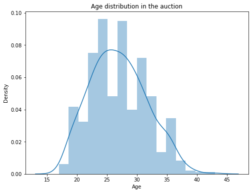

```python
sns.set_color_codes("pastel")
f, ax = plt.subplots(figsize=(8, 6))
sns.distplot(IPL1["Age"])
plt.title("Age distribution in the auction")
plt.show()
```

# Sold Players analysis:

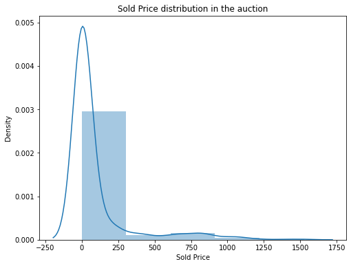

```python
sns.set_color_codes("pastel")
f, ax = plt.subplots(figsize=(8, 6))
sns.distplot(IPL1["Sold Price"], bins=5)
plt.title("Sold Price distribution in the auction")
plt.show()
```

# Finding the youngest and eldest sold player in IPL auction:

```python
IPL1[(IPL1["Bid"] == "Sold") & (IPL1["Age"] == IPL1["Age"].min())]
```

[output not shown]

```python
maxSoldAge = IPL1[IPL1["Bid"] == "Sold"]["Age"].max()
```

```python
IPL1[(IPL1["Age"] == maxSoldAge) & (IPL1["Bid"] == "Sold")]
```

[output not shown]

```python
print("Average age of players sold in auction is {}".format(int(IPL1[IPL1["Bid"] == "Sold"]["Age"].mean())))

print("Youngest Player sold is {} having age of {} years".
      format(IPL1[(IPL1["Bid"] == "Sold") & (IPL1["Age"] == IPL1["Age"].min())]["Player"].to_string(index=False),
             IPL1[(IPL1["Bid"] == "Sold") & (IPL1["Age"] == IPL1["Age"].min())]["Age"].to_string(index=False)))

print("Eldest Player sold is {} having age of {} years".
      format(IPL1[(IPL1["Age"] == maxSoldAge) & (IPL1["Bid"] == "Sold")]["Player"].to_string(index=False),
             IPL1[(IPL1["Age"] == maxSoldAge) & (IPL1["Bid"] == "Sold")]["Age"].to_string(index=False)))
```

```
Average age of players sold in auction is 27
Youngest Player sold is Noor Ahmad having age of 17 years
Eldest Player sold is Dwayne Bravo having age of 38 years
```

# Finding the youngest and eldest un-sold player in IPL auction:

```
> Average age of players sold in auction is 27
> Youngest Player sold is Noor Ahmad having age of 17 years
> Eldest Player sold is Dwayne Bravo having age of 38 years
```

```python
IPL1[(IPL1["Bid"] == "UnSold") & (IPL1["Age"] == IPL1["Age"].max())]
```

[output not shown]

```python
minUnSoldAge = IPL1[IPL1["Bid"] == "UnSold"]["Age"].min()
```

```python
IPL1[(IPL1["Age"] == minUnSoldAge) & (IPL1["Bid"] == "UnSold")]
```

[output not shown]

# Most expensive Indian and Overseas Player in IPL Auction:

```
 > Most expensive INDIAN player in the auction is Ishan Kishan at 1525.0 lakhs
 > Most expensive OVERSEAS player in the auction is Liam Livingstone at 1150.0 lakhs
```

```python
IPL3 = IPL1[IPL1["Country"] != "India"]
```

```python
IPL3
```

|  | Country | Player | State Association | IPL | Sold Price | Base Price | Previous IPLTeam(s) | 2021 Team | Bid | New Franchise | Increase Percentage |
| --- | --- | --- | --- | --- | --- | --- | --- | --- | --- | --- | --- |
| 0 | New Zealand | Trent Boult | F | 62.0 | 800.0 | 200 | SRH, KKR, DD,MI | MI | Sold | Rajasthan Royals | 300.0 |
| 1 | Australia | Pat Cummins | F | 37.0 | 725.0 | 200 | DD, MI, KKR | KKR | Sold | Kolkata Knight Riders | 262.5 |
| 4 | South Africa | Kagiso Rabada | F | 50.0 | 925.0 | 200 | DC | DC | Sold | Punjab Kings | 362.5 |
| 7 | South Africa | Quinton De Kock | F | 77.0 | 675.0 | 200 | SRH, DD, RCB, MI | MI | Sold | Lucknow Super Giants | 237.5 |
| 8 | South Africa | Faf Du Plessis | F | 100.0 | 700.0 | 200 | RPS, CSK | CSK | Sold | Royal Challengers Bangalore | 250.0 |
| ... | ... | ... | ... | ... | ... | ... | ... | ... | ... | ... | ... |
| 581 | West Indies | Mark Deyal | F | 0.0 | 0.0 | 20 | Do No Play | DNP | UnSold | Not Selected | 0.0 |
| 584 | Scotland | Safyaan Sharif | F | 0.0 | 0.0 | 20 | Do No Play | DNP | UnSold | Not Selected | 0.0 |
| 585 | New Zealand | Henry Shipley | F | 0.0 | 0.0 | 20 | Do No Play | DNP | UnSold | Not Selected | 0.0 |
| 587 | South Africa | Johan Van Dyk | F | 0.0 | 0.0 | 20 | Do No Play | DNP | UnSold | Not Selected | 0.0 |
| 588 | Sri Lanka | Dunith Wellalage | F | 0.0 | 0.0 | 20 | Do No Play | DNP | UnSold | Not Selected | 0.0 |

220 rows × 11 columns

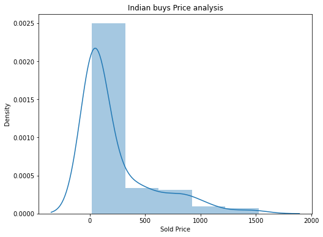

```python
sns.set_color_codes("pastel")
f, ax = plt.subplots(figsize=(8, 6))
sns.distplot(IPL1[(IPL1["Country"]=="India")&(IPL1["Bid"]=="Sold")]["Sold Price"], bins=5)
plt.title("Indian buys Price analysis")
plt.show()
```

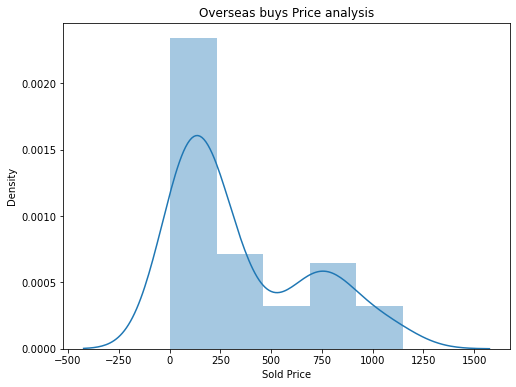

```python
sns.set_color_codes("pastel")
f, ax = plt.subplots(figsize=(8, 6))
sns.distplot(IPL3[IPL3["Bid"]=="Sold"]["Sold Price"], bins=5)
plt.title("Overseas buys Price analysis")
plt.show()
```

# Sold and Un-sold players in IPL Auction:

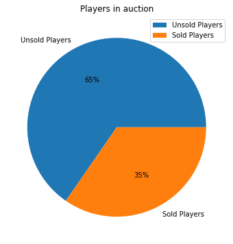

```python
sns.set_color_codes("pastel")
f, ax = plt.subplots(figsize=(8, 6))
labels = ["Unsold Players","Sold Players"]
plt.pie(IPL2["Bid"].value_counts(),labels=labels, autopct = "%0.0f%%")
plt.title("Players in auction")
plt.legend()
plt.show()
```

# Sold Players by India vs Overseas in IPL Auction:

```python
SoldPlayers = IPL2[IPL2["Bid"] == "Sold"]
```

```python
for i in range(len(SoldPlayers["Country"])):
    if SoldPlayers.iloc[i,3] != "India":
        SoldPlayers.iloc[i,3] = "Overseas"
```

```python
SoldPlayers
```

|  | Set No. | Set Name | Player | Country | State Association | Age | Specialism | Batting | Bowling | IPL | Previous IPLTeam(s) | 2021 Team | C/U/A | Base Price | Sold Price | New Franchise | Bid | Increase Percentage |
| --- | --- | --- | --- | --- | --- | --- | --- | --- | --- | --- | --- | --- | --- | --- | --- | --- | --- | --- |
| 0 | 1 | M | Trent Boult | Overseas | NaN | 32 | BOWLER | RHB | LEFT ARM Fast Medium | 62.0 | SRH, KKR, DD,MI | MI | Capped | 200 | 8 CR | Rajasthan Royals | Sold | 300.0 |
| 1 | 1 | M | Pat Cummins | Overseas | NaN | 28 | ALL-ROUNDER | RHB | RIGHT ARM Fast | 37.0 | DD, MI, KKR | KKR | Capped | 200 | 7.25 CR | Kolkata Knight Riders | Sold | 262.5 |
| 2 | 1 | M | Shikhar Dhawan | India | DDCA | 36 | BATSMAN | LHB | - | 192.0 | DCH, MI, SRH, DC | DC | Capped | 200 | 8.25 CR | Punjab Kings | Sold | 312.5 |
| 3 | 1 | M | Shreyas Iyer | India | MCA | 27 | BATSMAN | RHB | RIGHT ARM Leg Spin | 87.0 | DC | DC | Capped | 200 | 12.25 CR | Kolkata Knight Riders | Sold | 512.5 |
| 4 | 1 | M | Kagiso Rabada | Overseas | NaN | 26 | BOWLER | LHB | RIGHT ARM Fast | 50.0 | DC | DC | Capped | 200 | 9.25 CR | Punjab Kings | Sold | 362.5 |
| ... | ... | ... | ... | ... | ... | ... | ... | ... | ... | ... | ... | ... | ... | ... | ... | ... | ... | ... |
| 269 | 25 | UAL3 | B. Sai Sudharsan | India | TNCA | 20 | ALL-ROUNDER | LHB | RIGHT ARM Leg Spin | NaN | NaN | NaN | Uncapped | 20 | 20 L | Gujarat Titans | Sold | 0.0 |
| 270 | 25 | UAL3 | Atharva Taide | India | VCA | 21 | ALL-ROUNDER | LHB | LEFT ARM Slow Orthodox | NaN | NaN | NaN | Uncapped | 20 | 20 L | Punjab Kings | Sold | 0.0 |
| 295 | 29 | BA4 | Bhanuka Rajapaksa | Overseas | NaN | 30 | BATSMAN | LHB | - | NaN | NaN | NaN | Capped | 50 | 50 L | Punjab Kings | Sold | 0.0 |
| 500 | 53 | UAL8 | Mohd. Arshad Khan | India | MPCA | 24 | ALL-ROUNDER | LHB | LEFT ARM Fast Medium | NaN | NaN | NaN | Uncapped | 20 | 20 L | Mumbai Indians | Sold | 0.0 |
| 503 | 53 | UAL8 | K.Bhagath Varma | India | HYCA | 23 | ALL-ROUNDER | RHB | RIGHT ARM Off Spin | 0.0 | CSK | CSK | Uncapped | 20 | 20 L | Chennai Super Kings | Sold | 0.0 |

204 rows × 18 columns

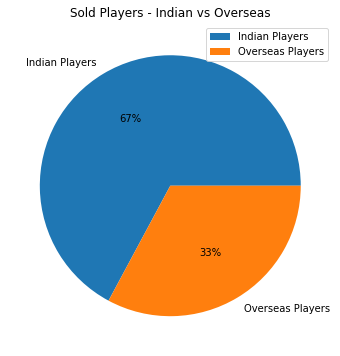

```python
sns.set_color_codes("pastel")
f, ax = plt.subplots(figsize=(8, 6))
labels = ["Indian Players","Overseas Players"]
plt.pie(SoldPlayers["Country"].value_counts(),labels=labels, autopct = "%0.0f%%")
plt.title("Sold Players - Indian vs Overseas")
plt.legend()
plt.show()
```

# Sold Players by Sold price and Base price in IPL Auction:

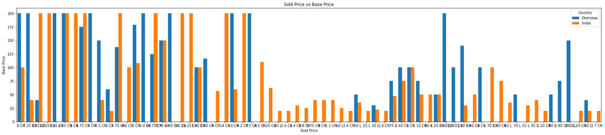

```python
sns.set_color_codes("pastel")
f, ax = plt.subplots(figsize=(30, 6))
sns.barplot(SoldPlayers["Sold Price"], SoldPlayers["Base Price"],hue=SoldPlayers["Country"],ci=None,saturation = 1)
plt.title("Sold Price vs Base Price")
plt.show()
```

# Trends in Sold Price on the basis of Base Price in IPL Auction:

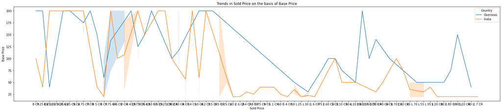

```python
sns.set_color_codes("pastel")
f, ax = plt.subplots(figsize=(30, 6))
sns.lineplot(x="Sold Price", y="Base Price",  hue="Country",data=SoldPlayers)
plt.title("Trends in Sold Price on the basis of Base Price")
plt.show()
```

# Indian Players from each state association in IPL Auction:

```python
State_Association = SoldPlayers["State Association"].value_counts().to_frame().reset_index()
```

```python
State_Association = State_Association.rename(columns={"index":"State Association","State Association":"Number of Players"})
```

```python
State_Association.drop(0,axis=0, inplace=True)
```

```python
State_Association.head(5)
```

|  | State Association | Number of Players |
| --- | --- | --- |
| 1 | TNCA | 13 |
| 2 | KSCA | 13 |
| 3 | UPCA | 12 |
| 4 | PCA | 11 |
| 5 | MCA | 9 |

```python
State_Association = State_Association.rename(columns={"Number of Sold Players":'State Association',
                                                      "Number of Players":'Number of Sold Players'})
```

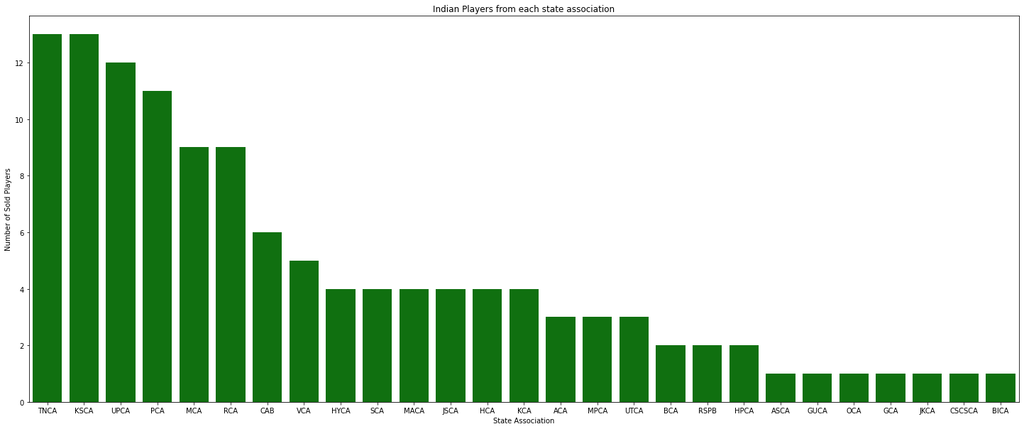

```python
sns.set_color_codes("pastel")

f, ax = plt.subplots(figsize=(25, 10))
sns.barplot(y="Number of Sold Players", x="State Association", data=State_Association, color="green")
plt.title("Indian Players from each state association")
plt.show()
```

# Max and Min State Association players in IPL Auction:

```python
MaxPlayerStates=State_Association[State_Association["Number of Sold Players"]==State_Association["Number of Sold Players"].
                                  max()]["State Association"].to_string(index=False).split('\n')
```

```python
MaxPlayerStates
```

```
['TNCA', 'KSCA']
```

```python
MinPlayerStates=State_Association[State_Association["Number of Sold Players"]==State_Association["Number of Sold Players"].
                                  min()]["State Association"].to_string(index=False).split('\n')
```

```python
MinPlayerStates
```

```
['  ASCA', '  GUCA', '   OCA', '   GCA', '  JKCA', 'CSCSCA', '  BICA']
```

# Sold Players - Capped and Uncapped in IPL Auction:

```python
IPL2["C/U/A"].value_counts()
```

```
Uncapped     354
Capped       228
Associate      7
Name: C/U/A, dtype: int64
```

[figure not shown]

```python
sns.set_color_codes("pastel")
f, ax = plt.subplots(figsize=(5, 5))

plt.pie(SoldPlayers["C/U/A"].value_counts(),labels=labels, autopct = "%0.0f%%",colors=["xkcd:cyan","tab:pink"])

ax.legend(labels,loc=0,title ="Players")
plt.title("Sold Players: Capped vs Uncapped")
labels = ["Uncapped Players","Capped Players"]
plt.legend()
plt.show()
```

# Franchise_Players - Squad size of each team in IPL Auction:

```python
Franchise_Players = SoldPlayers["New Franchise"].value_counts().to_frame().reset_index()
```

```python
Franchise_Players.rename(columns={"index":"Team","New Franchise":"Total Players"},inplace=True)
```

```python
Franchise_Players
```

|  | Team | Total Players |
| --- | --- | --- |
| 0 | Punjab Kings | 23 |
| 1 | Rajasthan Royals | 21 |
| 2 | Kolkata Knight Riders | 21 |
| 3 | Chennai Super Kings | 21 |
| 4 | Mumbai Indians | 21 |
| 5 | Delhi Capitals | 20 |
| 6 | Sunrisers Hyderabad | 20 |
| 7 | Gujarat Titans | 19 |
| 8 | Royal Challengers Bangalore | 19 |
| 9 | Lucknow Super Giants | 17 |
| 10 | Luknow Super Giants | 1 |
| 11 | Gujarat Titan | 1 |

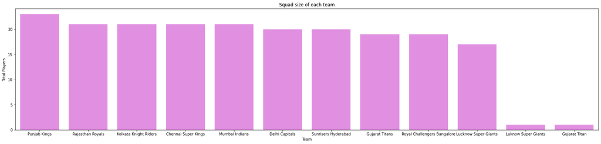

```python
f, ax = plt.subplots(figsize=(28,6))
sns.barplot(y="Total Players", x="Team", data=Franchise_Players,color="violet")
plt.title("Squad size of each team")
plt.show()
```

```python
print("Squad size of Punjab Kings is maximum with{} players".
      format(Franchise_Players[Franchise_Players["Team"]=="Punjab Kings"]["Total Players"].to_string(index=False)))

print("Squad size of Lucknow Super Giants is minimum with{} players".
      format(Franchise_Players[Franchise_Players["Team"]=="Lucknow Super Giants"]["Total Players"].to_string(index=False)))
```

```
Squad size of Punjab Kings is maximum with23 players
Squad size of Lucknow Super Giants is minimum with17 players
```

# Speciality:

```python
IPL2.head(3)
```

|  | Set No. | Set Name | Player | Country | State Association | Age | Specialism | Batting | Bowling | IPL | Previous IPLTeam(s) | 2021 Team | C/U/A | Base Price | Sold Price | New Franchise | Bid | Increase Percentage |
| --- | --- | --- | --- | --- | --- | --- | --- | --- | --- | --- | --- | --- | --- | --- | --- | --- | --- | --- |
| 0 | 1 | M | Trent Boult | New Zealand | NaN | 32 | BOWLER | RHB | LEFT ARM Fast Medium | 62.0 | SRH, KKR, DD,MI | MI | Capped | 200 | 8 CR | Rajasthan Royals | Sold | 300.0 |
| 1 | 1 | M | Pat Cummins | Australia | NaN | 28 | ALL-ROUNDER | RHB | RIGHT ARM Fast | 37.0 | DD, MI, KKR | KKR | Capped | 200 | 7.25 CR | Kolkata Knight Riders | Sold | 262.5 |
| 2 | 1 | M | Shikhar Dhawan | India | DDCA | 36 | BATSMAN | LHB | - | 192.0 | DCH, MI, SRH, DC | DC | Capped | 200 | 8.25 CR | Punjab Kings | Sold | 312.5 |

```python
Speciality = SoldPlayers["Specialism"].value_counts().to_frame().reset_index().rename(columns={"index":"Speciality","Specialism":"Total Players"})
```

```python
Speciality
```

|  | Speciality | Total Players |
| --- | --- | --- |
| 0 | ALL-ROUNDER | 77 |
| 1 | BOWLER | 69 |
| 2 | BATSMAN | 36 |
| 3 | WICKETKEEPER | 22 |

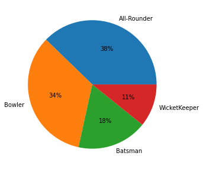

```python
sns.set_color_codes("pastel")
f, ax = plt.subplots(figsize=(7, 5))
label = ["All-Rounder","Bowler","Batsman","WicketKeeper"]
plt.pie(Speciality["Total Players"],labels=label,autopct = "%0.0f%%")
plt.show()
```

```python
print("Most demanded players were {} ({} players)".
      format(Speciality[Speciality["Total Players"] == Speciality["Total Players"].
      max()]["Speciality"].to_string(index=False),Speciality["Total Players"].max()))

print('Most demanded players were {} ({} players)'.
      format(Speciality[Speciality["Total Players"] == Speciality["Total Players"].
      min()]["Speciality"].to_string(index=False),Speciality["Total Players"].min()))
```

[output not shown]

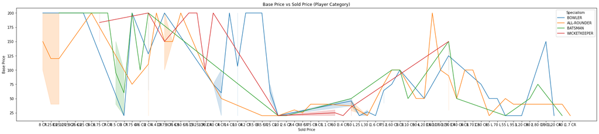

```python
sns.set_color_codes("pastel")
f, ax = plt.subplots(figsize=(30, 6))
sns.lineplot(x=SoldPlayers["Sold Price"], y=SoldPlayers["Base Price"],hue=SoldPlayers["Specialism"])
plt.title("Base Price vs Sold Price (Player Category)")
plt.show()
```

# All the important stats and numbers from the IPL 2022 mega auction

```
> 54801.9 Lacs were spent in the TATA IPL Auction 2022
> 204 players sold in the TATA IPL Auction 2022 (Overseas 67)
> Biggest buy at auction: Ishan Kishan (India, Mumbai Indians) Rs 1525.0 Lacs
> Biggest Overseas buy at auction: Liam Livingstone (England, Punjab Kings) Rs 1150.0 Lacs
```

# Replacing Team name with some specific value

```
1.Rajasthan Royals
2.Kolkata Knight Riders
3.Punjab Kings
4.Royal Challengers Bangalore
5.Delhi Capitals
6.Chennai Super Kings
7.Sunrisers Hyderabad
8.Mumbai Indians
```

```python
IPL4=pd.read_csv("C:\\Users\\Tanuja\\Desktop\\DATA-SET\\IPL_Auction_2022_FullList.csv",usecols=["New Franchise"])
IPL4
```

|  | New Franchise |
| --- | --- |
| 0 | Rajasthan Royals |
| 1 | Kolkata Knight Riders |
| 2 | Punjab Kings |
| 3 | Kolkata Knight Riders |
| 4 | Punjab Kings |
| ... | ... |
| 584 | NaN |
| 585 | NaN |
| 586 | NaN |
| 587 | NaN |
| 588 | NaN |

589 rows × 1 columns

```python
IPL4.replace({"Rajasthan Royals":1,"Kolkata Knight Riders":2,"Punjab Kings":3,"Royal Challengers Bangalore":4,
             "Delhi Capitals":5,"Chennai Super Kings":6,"Sunrisers Hyderabad":7,"Mumbai Indians":8})
```

|  | New Franchise |
| --- | --- |
| 0 | 1 |
| 1 | 2 |
| 2 | 3 |
| 3 | 2 |
| 4 | 3 |
| ... | ... |
| 584 | NaN |
| 585 | NaN |
| 586 | NaN |
| 587 | NaN |
| 588 | NaN |

589 rows × 1 columns

# Highest bid in IPL Auction:

```
> Punjab Kings(72 CR) & Sunrisers Hyderabad(68 CR) had the higgest amount in its purse.
> So the last two days they was seen bidding heavily on the players.
> Mumbai Indians had 48 CR in its purse but on last day they was seen bidding heavily on the players
```

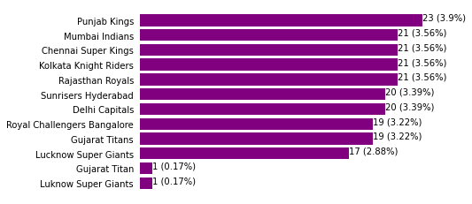

```python
def Franchise_plot(Franchise):
    Franchise_counts = Franchise.value_counts().sort_values(ascending=True)
    fig, ax = plt.subplots()

    bars = ax.barh(range(len(Franchise_counts)), Franchise_counts, color="purple")
    ax.set_frame_on(False)
    ax.tick_params(left=False, bottom=False, labelbottom=False)
    ax.set_yticks(range(len(Franchise_counts)))
    ax.set_yticklabels(Franchise_counts.index)

    for i,bar in enumerate(bars):
        value = bar.get_width()
        ax.text(value,bar.get_y() + bar.get_height()/2, '{:,} ({:}%)'.format(int(value), round(value*100/590,2)))

Franchise_plot(IPL2["New Franchise"])
plt.show()
```

# Finding which country has paid more in IPL Auction:

```
   > West Indian, Australia, New Zealand and England players have always been crucial to thier respective previous IPL          Teams in the  IPL but Liam Livingstone earned big money in the IPL.
   > West Indies players continue to draw big bids with SRH making Nicholas Pooran the highest-paid West Indian in the          IPL,shelling out Rs 10.75 CR for him.
```

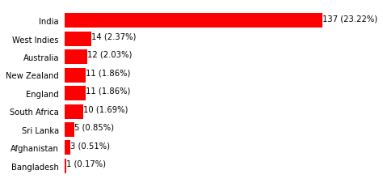

```python
country_counts = IPL2[IPL2.Bid=="Sold"].groupby("Country").size().sort_values()
fig, ax = plt.subplots()

bars = ax.barh(range(len(country_counts)), country_counts, color="red")
ax.set_frame_on(False)
ax.tick_params(left=False, bottom=False, labelbottom=False)
ax.set_yticks(range(len(country_counts)))
ax.set_yticklabels(country_counts.index)

for i,bar in enumerate(bars):
    value = bar.get_width()
    ax.text(value,bar.get_y() + bar.get_height()/2, "{:,} ({:}%)".format(int(value), round(value*100/590,2)))
plt.show()
```

# Finding the smallest to highest association in IPL 2022:

```
> Among the 370 Indian players, 61 are capped and 309 are uncapped with total of 34 state or union territory cricket         association's players involved.
> Tamil Nadu dominate the list with 30 players having registered for the auctions followed by Delhi(27), Karnataka and       UP(26).
> The biggest earners at the IPL auction for the 2022 season turned out to be local players, something which is unusual       from Tamil Nadu, Delhi, Karnataka, UP & Punjab Association
```

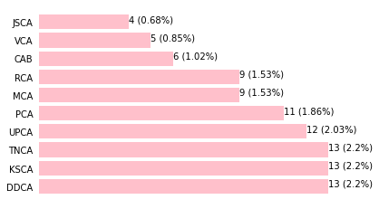

```python
association_counts = IPL2[IPL2.Bid=="Sold"]["State Association"].value_counts().sort_values(ascending=False).head(10)
fig, ax = plt.subplots()

bars = ax.barh(range(len(association_counts)), association_counts, color="pink")
ax.set_frame_on(False)
ax.tick_params(left=False, bottom=False, labelbottom=False)
ax.set_yticks(range(len(association_counts)))
ax.set_yticklabels(association_counts.index)

for i,bar in enumerate(bars):
    value = bar.get_width()
    ax.text(value,bar.get_y() + bar.get_height()/2, "{:,} ({:}%)".format(int(value), round(value*100/590,2)))
plt.show()
```

# Let's have a look at which top 10 players have made the most appearances in IPL:

```
> Dinesh Karthik has appeared the most number of times with a total figure of 213 apprearances from auction list.
> The IPL has had legends of the game playing in the tournament and pilling numbers over the last decade.
> More than 30 cricketers have gone on to play more than 100 IPL games over the last 12 years while more than 500 other       players have played less than 100.
```

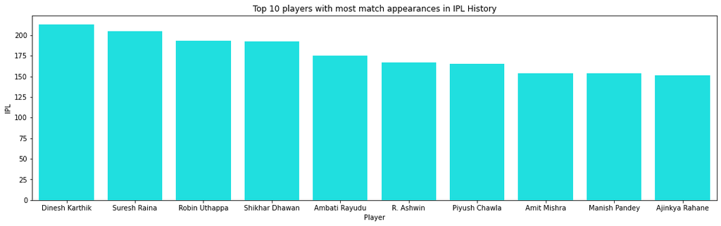

```python
plt.figure(figsize=(18,5))
plt.title("Top 10 players with most match appearances in IPL History")
sns.barplot(x=IPL2.sort_values(by=["IPL"],ascending=False)["Player"].head(10),
            y=IPL2.sort_values(by=["IPL"],ascending=False)["IPL"].head(10),color="cyan");
plt.show()
```

# Top 10 buys in IPL 2022 history:

```
> The biggest earners at the IPL auction for the 2022 season turned out to be local players,
something which is unusual.
> The three most expensive buys are Ishan Kishan, Deepak Chahar and Shreyas Iyer were all Indians.
> The only other time that happened was in 2011, when the top seven winning bids were on Indian players only.
> In fact, until 2021, 2013 players had earned INR 10 crore or higher bids, out of which seven were overseas players.
> The 2022 auction had 11 players touching the 10-crore mark, but only four were foreigners.
```

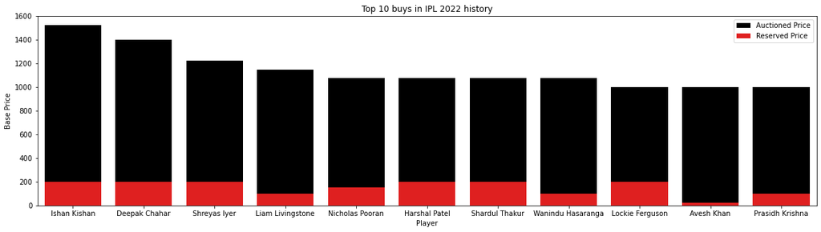

```python
plt.figure(figsize=(20,5))
plt.title("Top 10 buys in IPL 2022 history")

sns.barplot(x=IPL1.sort_values(by=["Sold Price"],ascending=False)["Player"].head(11),
            y=IPL1.sort_values(by=["Sold Price"],ascending=False)["Sold Price"].head(11),color="black",
            label="Auctioned Price")
sns.barplot(x=IPL1.sort_values(by=["Sold Price"],ascending=False)["Player"].head(11),
            y=IPL1.sort_values(by=["Sold Price"],ascending=False)["Base Price"].head(11),color="red",
            label="Reserved Price")

plt.legend()
plt.show()
```

# Biggest Increase to Previous Salary:

```
> Five players had seen their previous IPL salary raise by 2000% and more.
> 2 of them belonged to Sunrisers Hyderabad and rest 3 belonged to Lucknow, Gujarat and Punjab respectively.
> Aavesh Khan will now be 50 times richer, thanks to a INR 10 CR (USD 1.3 million) bid by Lucknow Super Giants
```

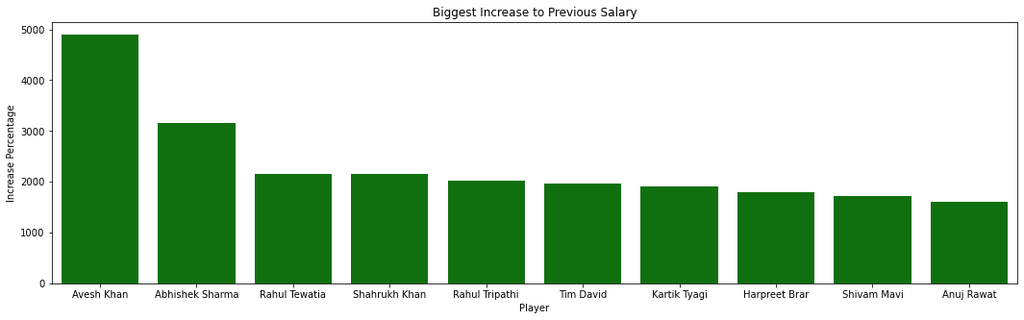

```python
plt.figure(figsize=(18,5))
plt.title("Biggest Increase to Previous Salary")
sns.barplot(x=IPL2.sort_values(by=["Increase Percentage"],ascending=False)["Player"].head(10),
            y=IPL2.sort_values(by=["Increase Percentage"],ascending=False)["Increase Percentage"].head(10),color="green");
```

# Capped and Un-capped Associates in IPL Auction:

[output not shown]

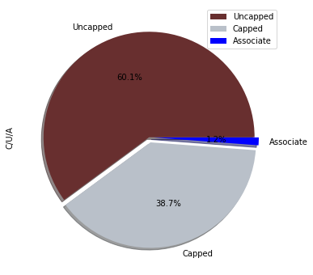

```python
fig = plt.figure(figsize=(8,6))

IPL2["C/U/A"].value_counts().plot.pie(explode=[0,0.05,0.04],autopct="%1.1f%%",shadow=True,
                                      colors=["#682F2F","#B9C0C9","blue"])

plt.legend()
plt.show()
```

# Speciality:

```
> One hundred and forty-six of the 204 players sold at the auction were either allrounders or bowlers.
> These players also went for big amounts.
> Only seven of the top 30 buys were either batters or wicketkeepers.
> Five of the 11 players to earn bids of INR 10 (USD 1.3 million) or more were bowlers.
> Three were allrounders.
> Two were hard-hitting wicketkeepers (Kishan and Nicholas Pooran).
> Only one was a specialist batter (Iyer).
```

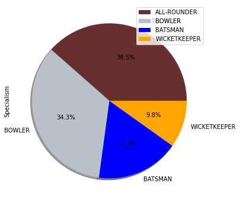

```python
fig = plt.figure(figsize=(8,6))
IPL2['Specialism'].value_counts().plot.pie(autopct='%1.1f%%',shadow=True,colors=["#682F2F","#B9C0C9","blue","orange"])

plt.legend()
plt.show()
```

# Mumbai Indians contrasting buys

[output not shown]

```python
IPL5=pd.DataFrame(IPL1[IPL1["New Franchise"]=="Mumbai Indians"].
                   sort_values(by="Sold Price",ascending=False,ignore_index=True)[["Player","Sold Price"]][0:4])

IPL5.loc[len(IPL5.index)] = ["Rest of Players",IPL1[IPL1["New Franchise"]=="Mumbai Indians"].
                               sort_values(by="Sold Price",ascending=False,ignore_index=False)["Sold Price"][4:].sum()]

IPL5.head()
```

|  | Player | Sold Price |
| --- | --- | --- |
| 0 | Ishan Kishan | 1525.0 |
| 1 | Tim David | 825.0 |
| 2 | Jofra Archer | 800.0 |
| 3 | Dewald Brevis | 300.0 |
| 4 | Rest of Players | 1340.0 |

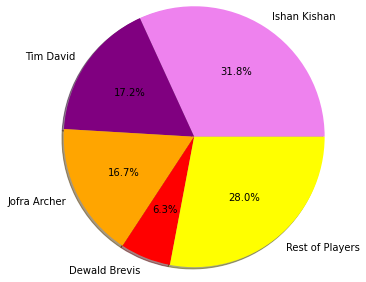

```python
plt.pie(x=IPL5["Sold Price"],labels=IPL5["Player"],autopct="%1.01f%%",
        shadow=True,radius=1.5,colors=["violet","purple","orange","red","yellow"])

plt.show()
```

# Chennai Super Kings contrasting buys:

[output not shown]

```python
IPL6=pd.DataFrame(IPL1[IPL1["New Franchise"]=="Chennai Super Kings"].
                   sort_values(by="Sold Price",ascending=False,ignore_index=True)[["Player","Sold Price"]][0:4])

IPL6.loc[len(IPL5.index)] = ["Rest of Players",IPL1[IPL1["New Franchise"]=="Chennai Super Kings"].
                               sort_values(by="Sold Price",ascending=False,ignore_index=False)["Sold Price"][4:].sum()]

IPL6.head()
```

|  | Player | Sold Price |
| --- | --- | --- |
| 0 | Deepak Chahar | 1400.0 |
| 1 | Ambati Rayudu | 675.0 |
| 2 | Dwayne Bravo | 440.0 |
| 3 | Shivam Dube | 400.0 |
| 5 | Rest of Players | 1401.9 |

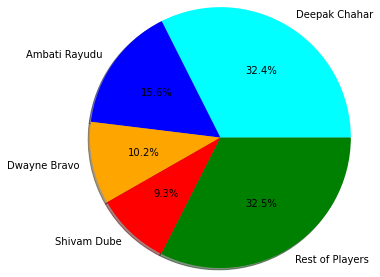

```python
plt.pie(x=IPL6["Sold Price"],labels=IPL6["Player"],autopct="%1.01f%%",
        shadow=True,radius=1.5,colors=["cyan","blue","orange","red","green"])

plt.show()
```

# Percentage of Batting:

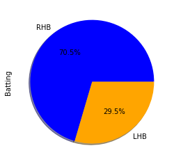

```python
fig=plt.figure(figsize=(18,9))
f1=fig.add_subplot(231)
IPL2['Batting'].value_counts().plot.pie(autopct='%1.1f%%',shadow=True,colors=["blue","orange"])
plt.show()
```

# Percentage of Bowling:

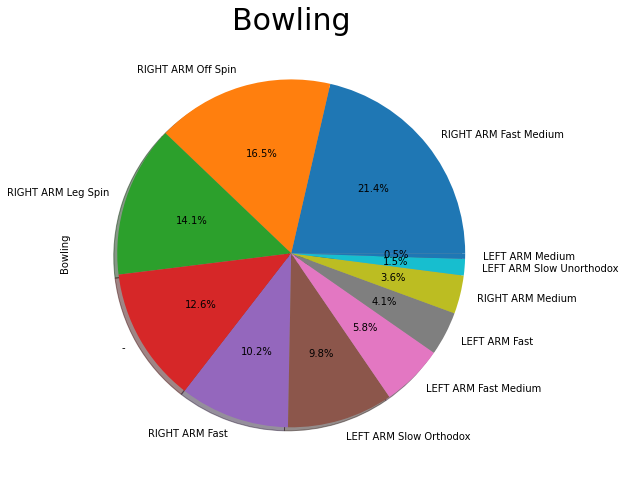

```python
fig=plt.figure(figsize=(18,8))
plt.title("Bowling",fontsize=30)
IPL["Bowling"].value_counts().plot.pie(autopct="%1.1f%%",shadow=True)
plt.show()
```

# Grouping the Base price and Sold Price of 2021 Team:

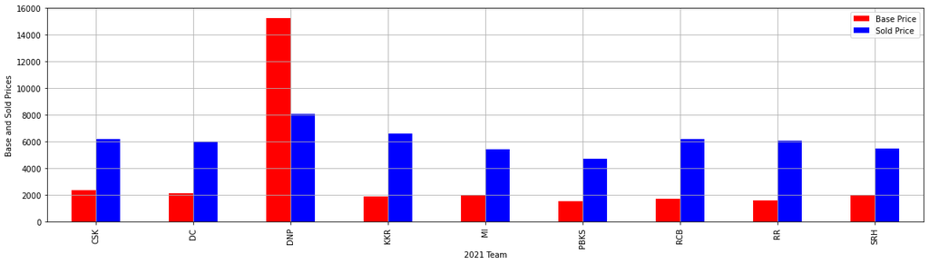

```python
IPL1.groupby("2021 Team")[["Base Price","Sold Price"]].sum().plot.bar(color=["red","blue"],figsize=(20,5))
plt.ylabel("Base and Sold Prices")
plt.grid()

plt.show()
```

# Checking the correlation of Base Price,Sold Price,Increase Percentage:

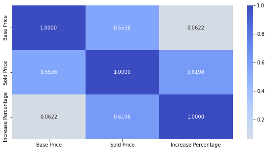

```python
n_IPL=["Base Price","Sold Price","Increase Percentage"]
plt.figure(figsize=(10,5))
sns.heatmap(IPL1[n_IPL].corr(),annot=True,fmt=".4f",cmap="coolwarm_r",center=0)
plt.show()
```

# Pairplot of New Franchise:

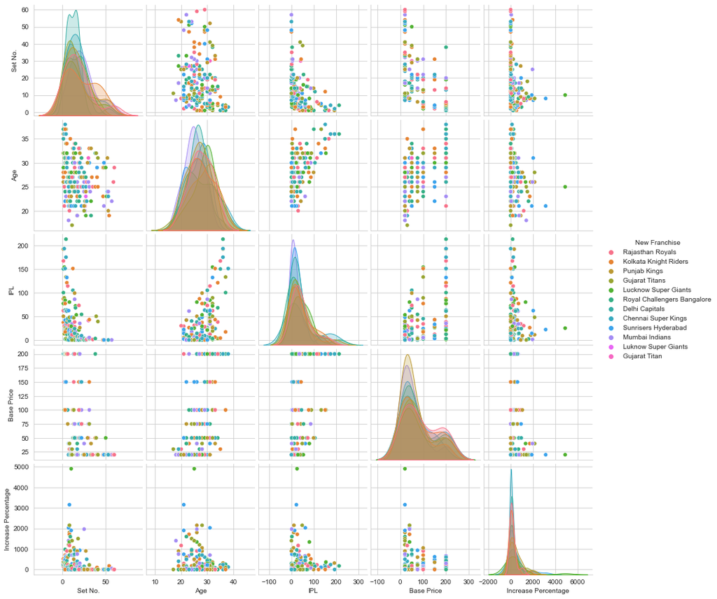

```python
sns.pairplot(IPL2,hue="New Franchise")
plt.show()
```

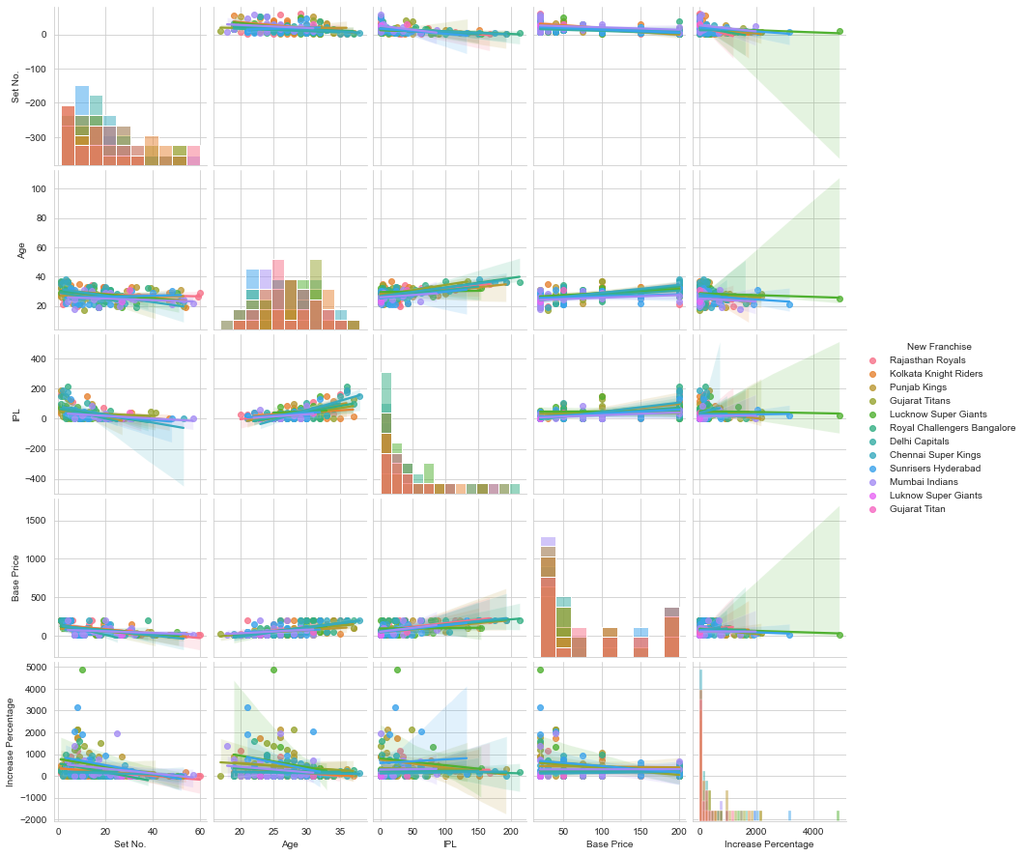

```python
sns.pairplot(IPL2,diag_kind="hist",kind="reg",hue="New Franchise")
plt.show()
```